# group_project_census_Group5

**Organization: National Institute of Economic Research (NIER)**

**Narrative:** The National Institute of Economic Research (NIER) conducts periodic socioeconomic surveys to gain insights into the financial well-being of the population. However, due to privacy concerns and ethical guidelines, the institute is not allowed to collect sensitive income data directly from respondents. Instead, they focus on gathering basic demographic information such as age, sex, education level, and marital status. This demographic data is collected in a way that ensures respondent anonymity and minimizes any potential discomfort or reluctance to participate. While NIER's goal is to avoid asking people about their income directly, understanding income distribution is crucial for formulating social welfare policies, identifying financial disparities, and tailoring public health programs. To address this, NIER needs to predict whether a respondent’s income is <=50K or >50K based on the available demographic data.

**Objective:**

**Approach:**

Explore the dataset to identify demographic and economic patterns. Evaluate income distribution across gender, race, education, and other key factors. Develop predictive models to understand how these factors contribute to income levels.

**Key Research Questions:**

How do education and occupation influence income inequality? Are there systemic barriers for certain races, genders, or marital statuses in achieving higher income? Which factors are the strongest predictors of high income?

**Expected Insights**

Educational Attainment: A clear correlation between higher education levels and increased income potential.

Gender Disparities: Evidence of systemic barriers or pay gaps based on gender. Racial Inequality: Insights into income distribution across different racial groups.

Occupational Trends: Identification of industries with higher earning potential.

Work Habits: Hours worked per week as a predictor of income level.

**Why just two income classifications (<50k or >50k)?**

**Description of column names:**

Age: The age of the individual.

Workclass: The type of employment (e.g., Private, Self-emp-not-inc, Federal-gov).

Fnlwgt: Final weight, representing the number of people in the U.S. represented by this individual in the survey.

Education: The highest level of education attained by the individual.

Education_Num: Numeric representation of the education level.

Marital_Status: The marital status of the individual. Occupation: The type of job held by the individual.

Relationship: The individual's relationship to others in the household.

Race: The race of the individual.

Sex: The gender of the individual.

Capital_Gain: The individual's capital gains from investments.

Capital_Loss: The individual's capital losses from investments.

Hours_Per_Week: The number of hours worked per week.

Native_Country: The country of origin of the individual. Income: The target variable indicating whether the individual earns <=50K or >50K.

**Variable Types**

age: continuous.

workclass: Private, Self-emp-not-inc, Self-emp-inc, Federal-gov, Local-gov, State-gov, Without-pay, Never-worked.

fnlwgt: continuous.

education: Bachelors, Some-college, 11th, HS-grad, Prof-school, Assoc-acdm, Assoc-voc, 9th, 7th-8th, 12th, Masters, 1st-4th, 10th, Doctorate, 5th-6th, Preschool.

education-num: continuous.

marital-status: Married-civ-spouse, Divorced, Never-married, Separated, Widowed, Married-spouse-absent, Married-AF-spouse.

occupation: Tech-support, Craft-repair, Other-service, Sales, Exec-managerial, Prof-specialty, Handlers-cleaners, Machine-op-inspct, Adm-clerical, Farming-fishing, Transport-moving, Priv-house-serv, Protective-serv, Armed-Forces.

relationship: Wife, Own-child, Husband, Not-in-family, Other-relative, Unmarried.

race: White, Asian-Pac-Islander, Amer-Indian-Eskimo, Other, Black.

sex: Female, Male.

capital-gain: continuous.

capital-loss: continuous.

hours-per-week: continuous.

native-country: United-States, Cambodia, England, Puerto-Rico, Canada, Germany, Outlying-US(Guam-USVI-etc), India, Japan, Greece, South, China, Cuba, Iran, Honduras, Philippines, Italy, Poland, Jamaica, Vietnam, Mexico, Portugal, Ireland, France, Dominican-Republic, Laos, Ecuador, Taiwan, Haiti, Columbia, Hungary, Guatemala, Nicaragua, Scotland, Thailand, Yugoslavia, El-Salvador, Trinadad&Tobago, Peru, Hong, Holand-Netherlands.

**Education Levels and Corresponding Numerical Codes:**

1: Preschool

2: 1st-4th (1st to 4th grade)

3: 5th-6th (5th to 6th grade)

4: 7th-8th (7th to 8th grade)

5: 9th (9th grade)

6: 10th (10th grade)

7: 11th (11th grade)

8: 12th (12th grade)

9: HS-grad (High School Graduate)

10: Some-college (Some college, but no degree)

11: Assoc-acdm (Associate's degree, academic program)

12: Assoc-voc (Associate's degree, vocational program)

**Lets start by importing libraries**

```python
import warnings
warnings.filterwarnings("ignore")

import pandas as pd
import numpy as np
import matplotlib.pyplot as plt
import seaborn as sns

# Library to split data
from sklearn.model_selection import train_test_split

# Libraries to import decision tree classifier and different ensemble classifiers
from sklearn.ensemble import BaggingClassifier
from sklearn.ensemble import RandomForestClassifier
from sklearn.tree import DecisionTreeClassifier
from sklearn import tree

# Libtune to tune model, get different metric scores
from sklearn import metrics
from sklearn.metrics import (
    confusion_matrix,
    classification_report,
    accuracy_score,
    precision_score,
    recall_score,
    f1_score,
    roc_auc_score,
)
from sklearn.model_selection import GridSearchCV
```

```python
#Mounting the google drive
from google.colab import drive
drive.mount('/content/drive')
```

**Load and overview the dataset**

```python
# Loading the dataset
data = pd.read_csv("/content/drive/MyDrive/BUSI 650/adult_data_updated.csv")
```

```python
data.shape
```

```
(32561, 15)
```

```python
data.head()
```

|  | Age | Workclass | Fnlwgt | Education | Education_Num | Marital_Status | Occupation | Relationship | Race | Sex | Capital_Gain | Capital_Loss | Hours_Per_Week | Native_Country | Income |
| --- | --- | --- | --- | --- | --- | --- | --- | --- | --- | --- | --- | --- | --- | --- | --- |
| 0 | 39 | State-gov | 77516 | Bachelors | 13 | Never-married | Adm-clerical | Not-in-family | White | Male | 2174 | 0 | 40 | United-States | <=50K |
| 1 | 50 | Self-emp-not-inc | 83311 | Bachelors | 13 | Married-civ-spouse | Exec-managerial | Husband | White | Male | 0 | 0 | 13 | United-States | <=50K |
| 2 | 38 | Private | 215646 | HS-grad | 9 | Divorced | Handlers-cleaners | Not-in-family | White | Male | 0 | 0 | 40 | United-States | <=50K |
| 3 | 53 | Private | 234721 | 11th | 7 | Married-civ-spouse | Handlers-cleaners | Husband | Black | Male | 0 | 0 | 40 | United-States | <=50K |
| 4 | 28 | Private | 338409 | Bachelors | 13 | Married-civ-spouse | Prof-specialty | Wife | Black | Female | 0 | 0 | 40 | Cuba | <=50K |

**Check the data types of the columns in the dataset.**

```python
data.info()
```

```
<class 'pandas.core.frame.DataFrame'>
RangeIndex: 32561 entries, 0 to 32560
Data columns (total 15 columns):
 #   Column          Non-Null Count  Dtype
---  ------          --------------  -----
 0   Age             32561 non-null  int64
 1   Workclass       32561 non-null  object
 2   Fnlwgt          32561 non-null  int64
 3   Education       32561 non-null  object
 4   Education_Num   32561 non-null  int64
 5   Marital_Status  32561 non-null  object
 6   Occupation      32561 non-null  object
 7   Relationship    32561 non-null  object
 8   Race            32561 non-null  object
 9   Sex             32561 non-null  object
 10  Capital_Gain    32561 non-null  int64
 11  Capital_Loss    32561 non-null  int64
 12  Hours_Per_Week  32561 non-null  int64
 13  Native_Country  32561 non-null  object
 14  Income          32561 non-null  object
dtypes: int64(6), object(9)
memory usage: 3.7+ MB
```

- The dataset has 32,561 entries and 15 columns
- The datatypes seem to be assigned correctly
- There are in total 6 continuous variables (Age, Fnlwgt, Education_Num, Capital_Gain, Capital_Loss, Hours_Per_Week)
- The remaining are categorical variables
- There seems to be no missing values as well

**Summary of the dataset**

```python
data.describe().T
```

|  | count | mean | std | min | 25% | 50% | 75% | max |
| --- | --- | --- | --- | --- | --- | --- | --- | --- |
| Age | 32561.0 | 38.581647 | 13.640433 | 17.0 | 28.0 | 37.0 | 48.0 | 90.0 |
| Fnlwgt | 32561.0 | 189778.366512 | 105549.977697 | 12285.0 | 117827.0 | 178356.0 | 237051.0 | 1484705.0 |
| Education_Num | 32561.0 | 10.080679 | 2.572720 | 1.0 | 9.0 | 10.0 | 12.0 | 16.0 |
| Capital_Gain | 32561.0 | 1077.648844 | 7385.292085 | 0.0 | 0.0 | 0.0 | 0.0 | 99999.0 |
| Capital_Loss | 32561.0 | 87.303830 | 402.960219 | 0.0 | 0.0 | 0.0 | 0.0 | 4356.0 |
| Hours_Per_Week | 32561.0 | 40.437456 | 12.347429 | 1.0 | 40.0 | 40.0 | 45.0 | 99.0 |

**Data Cleaning**

Fnlwgt represents a sampling weight from the Census, which is more relevant for population-level inferences, not individual-level income prediction. Let's drop the column.

```python
data = data.drop(columns=["Fnlwgt"])
```

**Checking for duplicate rows and dropping them**

```python
# Define the list of categorical columns
categorical_columns = ['Workclass', 'Education', 'Marital_Status', 'Occupation', 'Relationship', 'Race', 'Sex', 'Native_Country', 'Income']

# Define the list of numerical columns
numerical_columns = ['Age', 'Education_Num', 'Capital_Gain', 'Capital_Loss', 'Hours_Per_Week']

#Checking for duplicates
duplicates = data.duplicated().sum()

# Display the number of duplicate rows
duplicates
```

```
3465
```

```python
# Drop duplicate rows
data = data.drop_duplicates()

# Confirm by checking the shape of the dataset
data.shape
```

```
(29096, 14)
```

```python
# Check for invalid or unusual values in categorical columns
invalid_values_summary = {
    column: data[column].unique() for column in categorical_columns
}

# Check for statistical outliers in numerical columns
numerical_summary = data[numerical_columns].describe()

# Display findings: Duplicate rows, invalid values, and statistical summaries
{
    "Invalid Values in Categorical Columns": invalid_values_summary,
    "Statistical Summary of Numerical Columns": numerical_summary
}
```

```
{'Invalid Values in Categorical Columns': {'Workclass': array([' State-gov', ' Self-emp-not-inc', ' Private', ' Federal-gov',
         ' Local-gov', ' ?', ' Self-emp-inc', ' Without-pay',
         ' Never-worked'], dtype=object),
  'Education': array([' Bachelors', ' HS-grad', ' 11th', ' Masters', ' 9th',
         ' Some-college', ' Assoc-acdm', ' Assoc-voc', ' 7th-8th',
         ' Doctorate', ' Prof-school', ' 5th-6th', ' 10th', ' 1st-4th',
         ' Preschool', ' 12th'], dtype=object),
  'Marital_Status': array([' Never-married', ' Married-civ-spouse', ' Divorced',
         ' Married-spouse-absent', ' Separated', ' Married-AF-spouse',
         ' Widowed'], dtype=object),
  'Occupation': array([' Adm-clerical', ' Exec-managerial', ' Handlers-cleaners',
         ' Prof-specialty', ' Other-service', ' Sales', ' Craft-repair',
         ' Transport-moving', ' Farming-fishing', ' Machine-op-inspct',
         ' Tech-support', ' ?', ' Protective-serv', ' Armed-Forces',
         ' Priv-house-serv'], dtype=object),
  'Relationship': array([' Not-in-family', ' Husband', ' Wife', ' Own-child', ' Unmarried',
         ' Other-relative'], dtype=object),
  'Race': array([' White', ' Black', ' Asian-Pac-Islander', ' Amer-Indian-Eskimo',
         ' Other'], dtype=object),
  'Sex': array([' Male', ' Female'], dtype=object),
  'Native_Country': array([' United-States', ' Cuba', ' Jamaica', ' India', ' ?', ' Mexico',
         ' South', ' Puerto-Rico', ' Honduras', ' England', ' Canada',
         ' Germany', ' Iran', ' Philippines', ' Italy', ' Poland',
         ' Columbia', ' Cambodia', ' Thailand', ' Ecuador', ' Laos',
         ' Taiwan', ' Haiti', ' Portugal', ' Dominican-Republic',
         ' El-Salvador', ' France', ' Guatemala', ' China', ' Japan',
         ' Yugoslavia', ' Peru', ' Outlying-US(Guam-USVI-etc)', ' Scotland',
         ' Trinadad&Tobago', ' Greece', ' Nicaragua', ' Vietnam', ' Hong',
         ' Ireland', ' Hungary', ' Holand-Netherlands'], dtype=object),
  'Income': array([' <=50K', ' >50K'], dtype=object)},
 'Statistical Summary of Numerical Columns':                 Age  Education_Num  Capital_Gain  Capital_Loss  Hours_Per_Week
 count  29096.000000   29096.000000  29096.000000  29096.000000    29096.000000
 mean      39.251340      10.102695   1197.802206     97.175179       40.637820
 std       13.687157       2.645194   7778.225220    424.008232       12.735418
 min       17.000000       1.000000      0.000000      0.000000        1.000000
 25%       28.000000       9.000000      0.000000      0.000000       40.000000
 50%       38.000000      10.000000      0.000000      0.000000       40.000000
 75%       48.000000      13.000000      0.000000      0.000000       45.000000
 max       90.000000      16.000000  99999.000000   4356.000000       99.000000}
```

1. There is "?" values in categorical columns. Replacing "?" with NaN for better handling
2. Our project will focus on only data from united states. So, let's drop rows from other countries and remove the column

```python
# Step 2: Replace '?' values with NaN for easier handling in categorical columns
data = data.replace(' ?', pd.NA)
```

```python
#Dropping missing values
data.dropna(inplace=True)
```

```python
# Check the number of rows where 'Native_Country' is 'United-States'
us_data_count = data[data["Native_Country"] == " United-States"].shape[0]
us_data_count
```

```
24259
```

```python
#Remove data from other countries other than united states
# Filter the dataset to keep only rows where Native_Country is "United-States"
data_usa = data[data["Native_Country"] == " United-States"]
```

```python
#Remove Native_Country column from dataset
data_usa = data_usa.drop(columns=["Native_Country"])
```

```python
# Step 4: Recheck dataset for readiness after cleaning
cleaned_summary = {
    "Rows After Cleaning": data_usa.shape[0],
    "Columns After Cleaning": data.shape[1],
    "Missing Values After Cleaning": data.isnull().sum().sum()
}
cleaned_summary
```

```
{'Rows After Cleaning': 24259,
 'Columns After Cleaning': 14,
 'Missing Values After Cleaning': 0}
```

```python
data_usa.shape
```

```
(24259, 13)
```

**Lets perform univariate analysis**

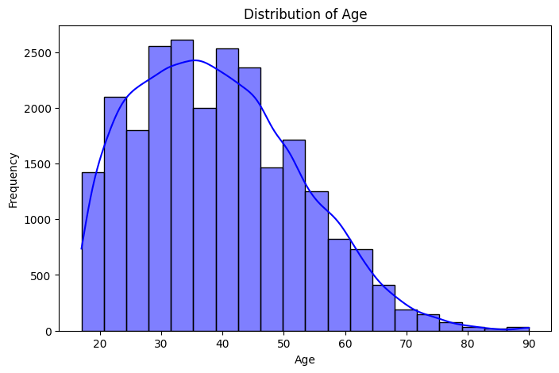

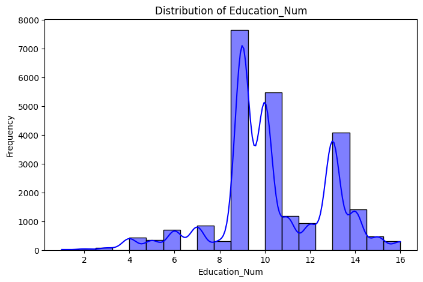

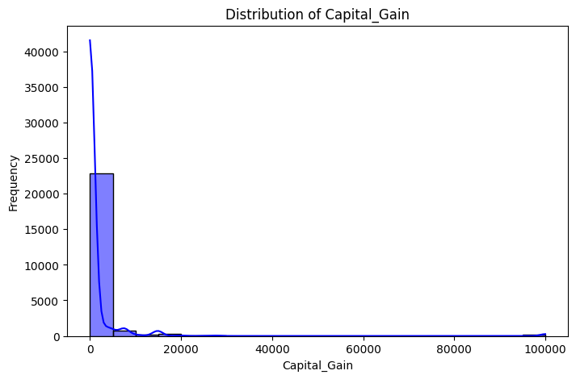

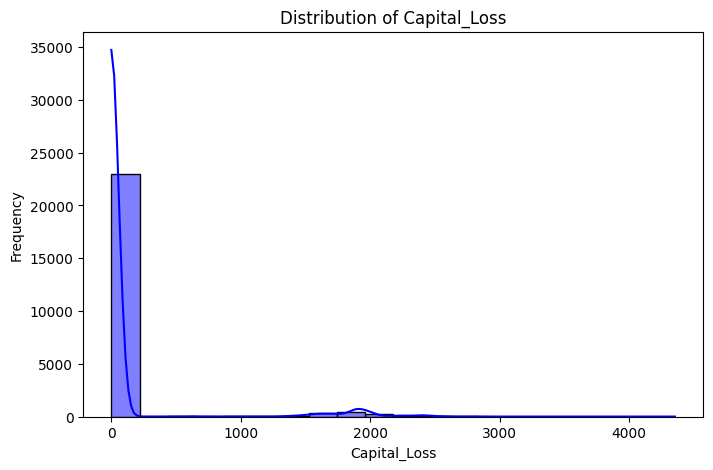

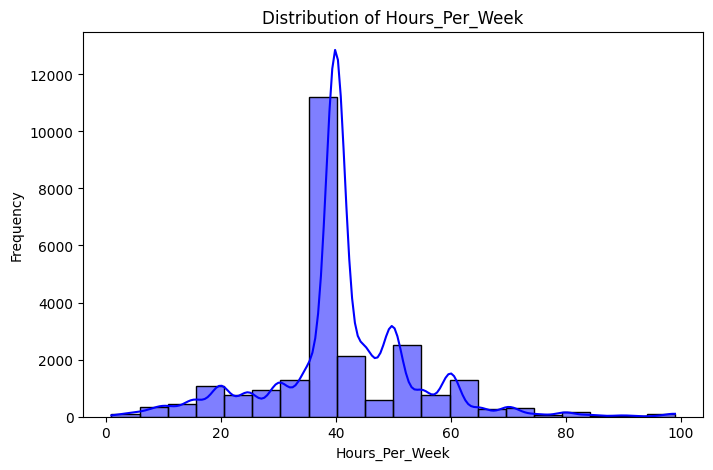

```python
# Function to plot histograms for numerical features
def plot_histograms(data_usa, numerical_columns):
    for column in numerical_columns:
        plt.figure(figsize=(8, 5))
        # Use data_usa instead of df and uploaded_dataset_df
        sns.histplot(data_usa[column], kde=True, bins=20, color="blue")
        plt.title(f"Distribution of {column}")
        plt.xlabel(column)
        plt.ylabel("Frequency")
        plt.show()

numerical_columns = ["Age", "Education_Num", "Capital_Gain", "Capital_Loss", "Hours_Per_Week"] # Removed 'Fnlwgt' as it was dropped earlier
# Visualize distributions for numerical features
# Use data_usa instead of uploaded_dataset_df
plot_histograms(data_usa, numerical_columns)
```

Summary for Numerical Features:

Age: Most individuals are from 20 to 50 years of age

Education_Num: Peaks at 9 (HS-grad) and 13 (Bachelors), reflecting common education levels.

Capital_Gain/Loss: Mostly zero, as expected, with few high values.

Hours_Per_Week: Peaks at 40 hours (standard work week) with a long tail

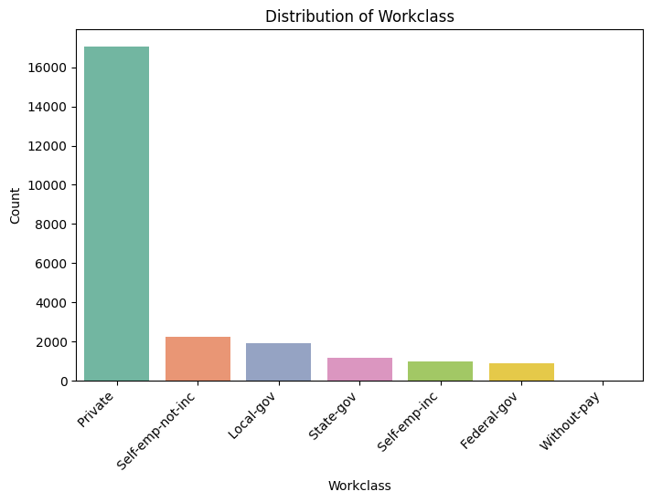

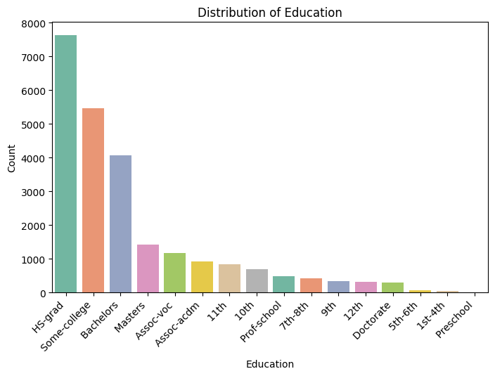

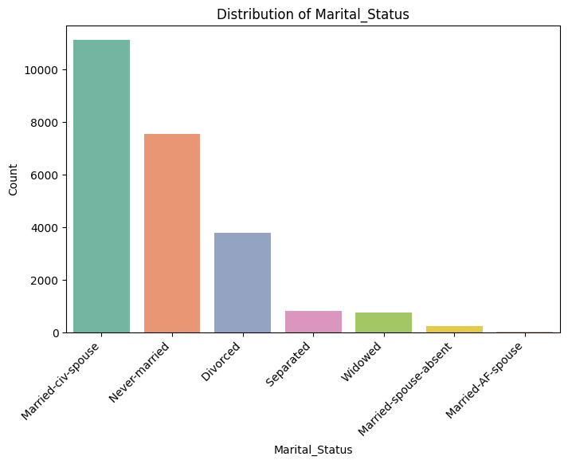

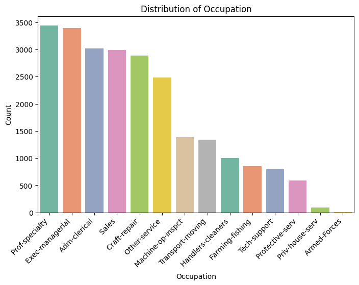

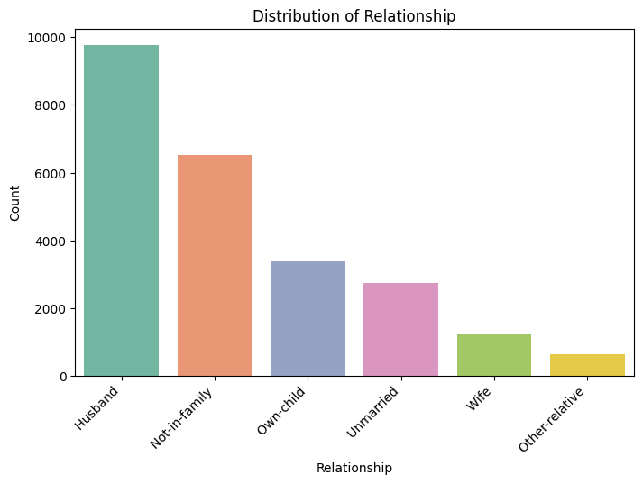

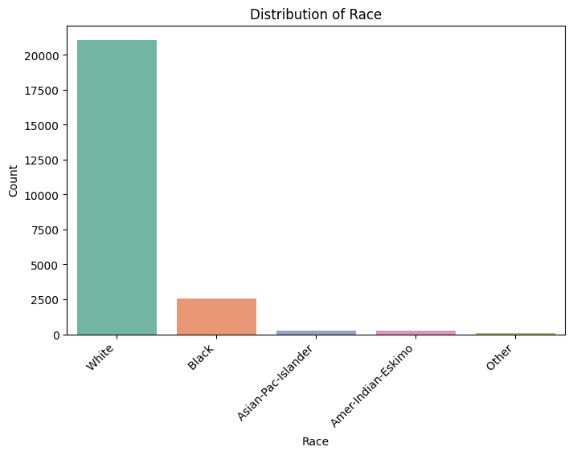

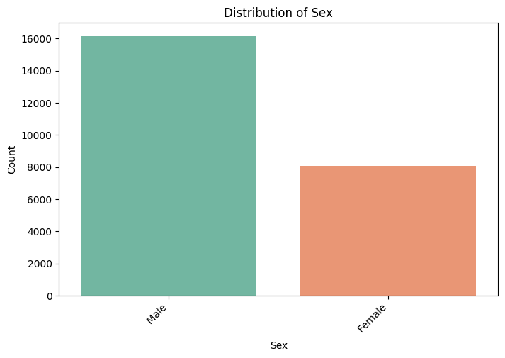

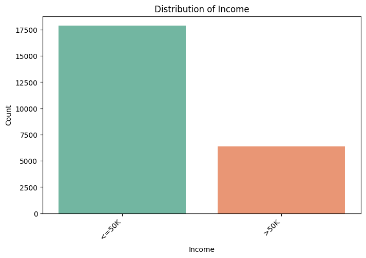

```python
# Function to plot bar plots for categorical features
def plot_barplots(data_usa, categorical_columns):
    for column in categorical_columns:
        plt.figure(figsize=(8, 5))
        sns.countplot(data=data_usa, x=column, order=data_usa[column].value_counts().index, palette="Set2") # Changed df to data_usa
        plt.title(f"Distribution of {column}")
        plt.xlabel(column)
        plt.ylabel("Count")
        plt.xticks(rotation=45, ha="right")
        plt.show()
categorical_columns = ["Workclass", "Education", "Marital_Status", "Occupation", "Relationship", "Race", "Sex", "Income"] # Assuming you want to retain the Native_Country for plotting

# Visualize distributions for categorical features
plot_barplots(data_usa, categorical_columns)
```

**Categorical Features:**

Workclass: Most individuals are in "Private" jobs, with smaller groups in "Self-emp" or government roles.

Education: Majority are high school graduates or college dropouts or has a bachelors degree.

Marital_Status: The dataset is dominated by individuals who are married, followed by "Never-married."

Occupation: Majority of individulas are Specialists, Manging Executives, Administrators, sales and crafts. while minority work in service industry

Relationship: Almost 10,000 out of 25,000 individuals are "Husbands"

Race: Predominantly "White," with smaller groups of "Black" and other races.

Sex: Males are almost twice as females

Income: The majority of individuals fall in the <=50K category.

**Lets perform Bivariate Analysis against the target variable**

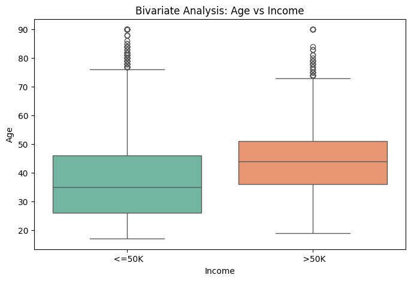

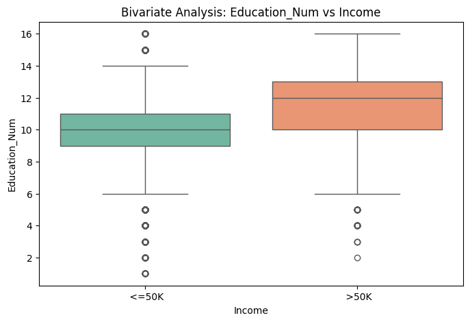

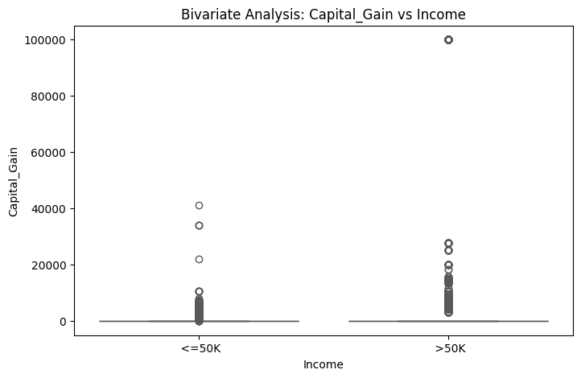

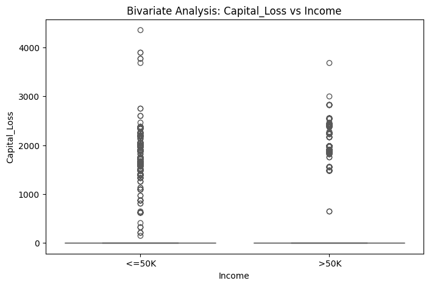

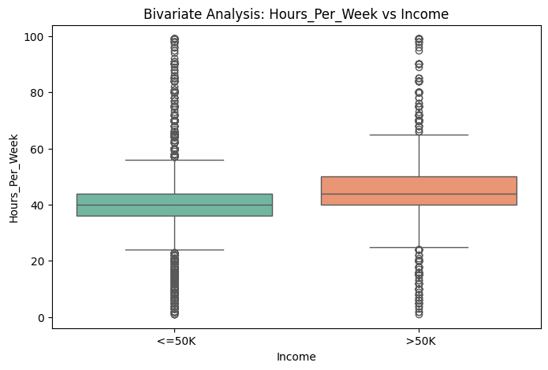

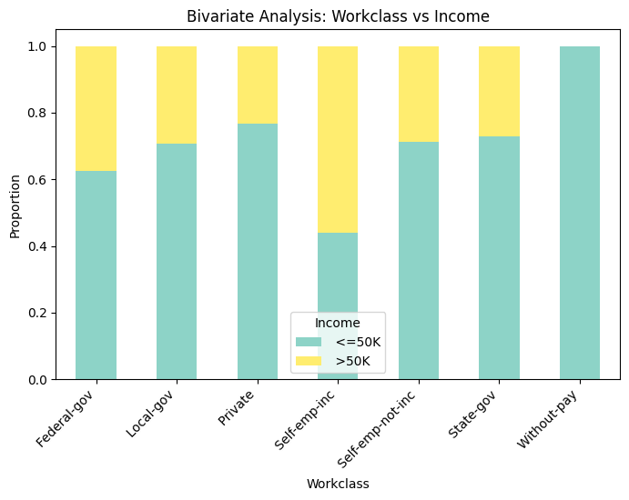

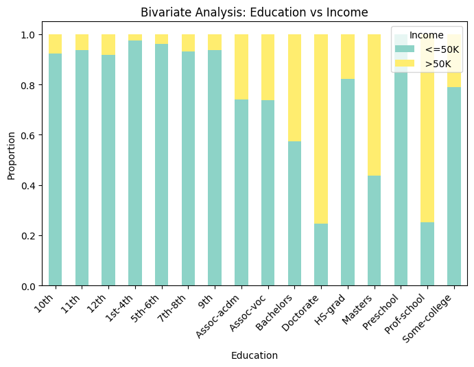

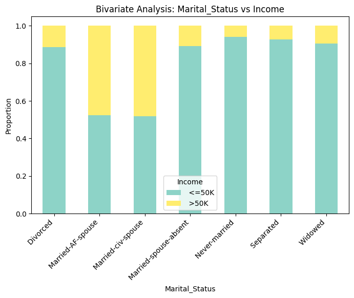

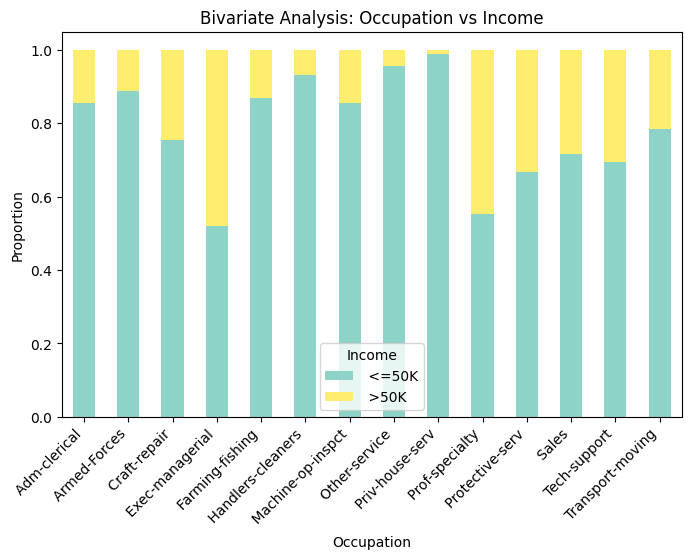

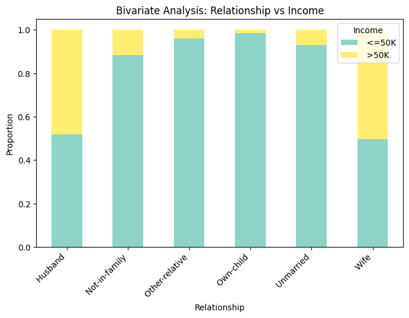

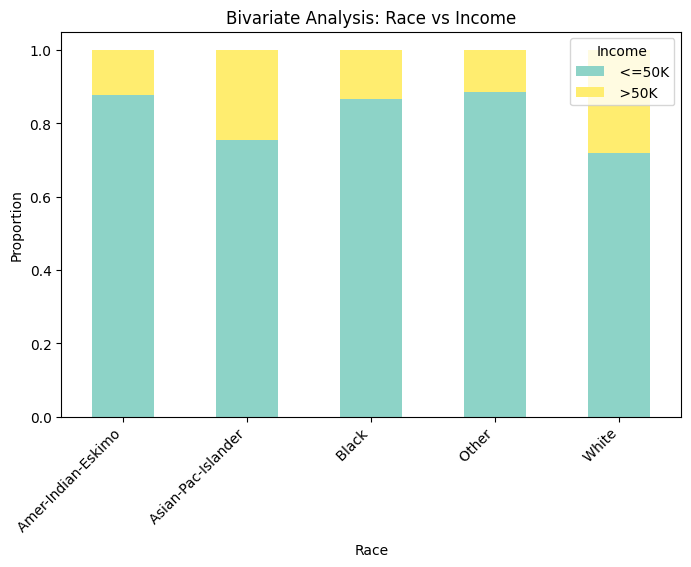

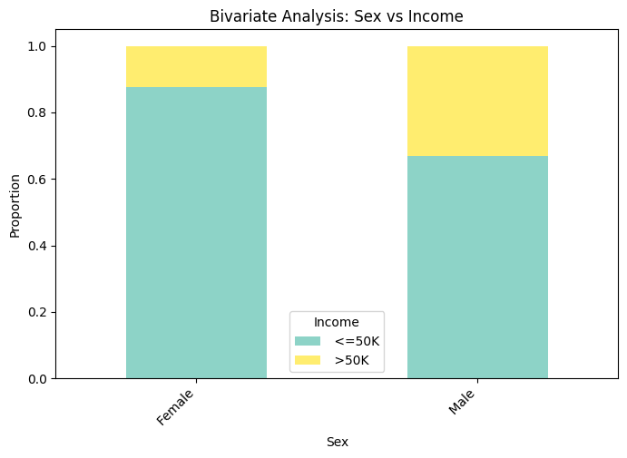

```python
# Step 1: Bivariate analysis for numerical columns against the target variable (Income)
def bivariate_numerical(data_usa, numerical_columns, target):
    for column in numerical_columns:
        plt.figure(figsize=(8, 5))
        sns.boxplot(data_usa, x=target, y=column, palette="Set2")
        plt.title(f"Bivariate Analysis: {column} vs {target}")
        plt.xlabel(target)
        plt.ylabel(column)
        plt.show()

# Step 2: Bivariate analysis for categorical columns against the target variable (Income)
def bivariate_categorical(data_usa, categorical_columns, target):
    for column in categorical_columns:
        plt.figure(figsize=(8, 5))
        category_counts = pd.crosstab(data_usa[column], data_usa[target], normalize="index")
        category_counts.plot(kind="bar", stacked=True, colormap="Set3", figsize=(8, 5))
        plt.title(f"Bivariate Analysis: {column} vs {target}")
        plt.xlabel(column)
        plt.ylabel("Proportion")
        plt.xticks(rotation=45, ha="right")
        plt.legend(title=target)
        plt.show()

# Perform bivariate analysis
target_variable = "Income"
bivariate_numerical(data_usa, numerical_columns, target_variable)
bivariate_categorical(data_usa, categorical_columns[:-1], target_variable)  # Exclude 'Income' from categorical columns
```

**Numerical Features vs Income:**

Age: Higher income (>50K) is more common among older individuals (peaks in the 40–60 age range). Younger individuals (<30) are more likely to fall in the <=50K category.

Education_Num: A strong positive relationship with income: Higher Education_Num values are associated with >50K.

Capital_Gain/Capital_Loss: Non-zero capital gain or loss is disproportionately associated with >50K. Capital gain outliers (e.g., ~99999) heavily influence the >50K category.

Hours_Per_Week: Individuals working longer hours (45+) are more likely to earn >50K. Most individuals with standard workweeks (~40 hours) fall in the <=50K category.

**Categorical Features vs Income:**

Education: Advanced degrees (e.g., Doctorate, Prof-school) have a much higher proportion of >50K. Lower education levels (e.g., HS-grad, Some-college) are skewed toward <=50K.

Marital_Status: Married individuals has the highest proportion of >50K. "Never-married" , "Absent spouse" "Divorced" skew toward <=50K.

Occupation: Specialists and executives dominate the >50K category. cleaning and service industry are skewed toward <=50K.

Relationship: "Husband" and "Wife" show high proportions of >50K. "Not-in-family" and "Own-child" are predominantly <=50K.

Race: "White" has the largest share of >50K. Other races have lower proportions, likely reflecting systemic disparities.

Sex: Males are significantly more likely to earn >50K compared to females.

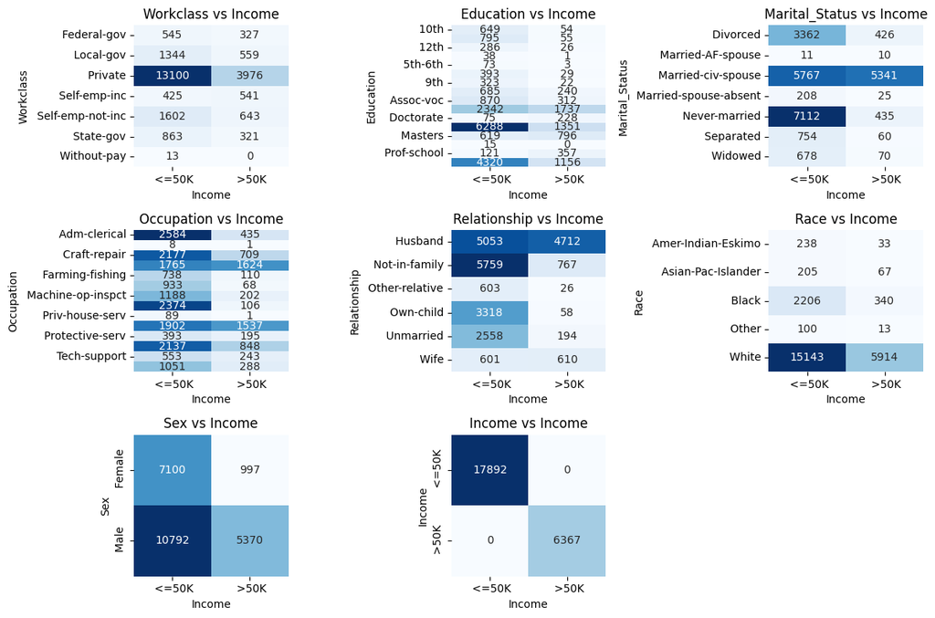

```python
# Cross-tabulation for categorical features vs Income
plt.figure(figsize=(12, 8))
for i, feature in enumerate(categorical_columns, 1):
    plt.subplot(3, 3, i)
    cross_tab = pd.crosstab(data_usa[feature], data['Income'])
    sns.heatmap(cross_tab, annot=True, fmt="d", cmap='Blues', cbar=False)
    plt.title(f'{feature} vs Income')
plt.tight_layout()
plt.show()
```

**Correlation metric for numerical features**

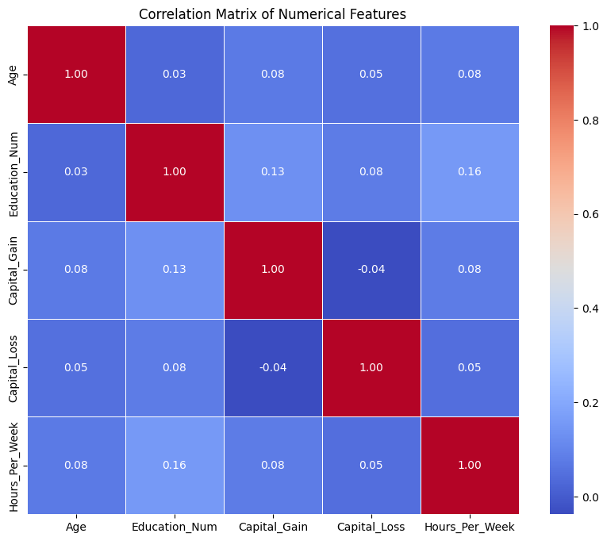

```python
# Heatmap for Correlation (for a more detailed view of correlations)
plt.figure(figsize=(10, 8))
sns.heatmap(data_usa[numerical_columns].corr(), annot=True, cmap='coolwarm', fmt='.2f', linewidths=0.5)
plt.title('Correlation Matrix of Numerical Features')
plt.show()
```

**Lets continue with the data preparation for modelling**

**Which loss is bigger?*8

It depends on NIER's goals and the context in which the model is used. In this case, the most important consideration is that NIER wants to capture as many individuals in the <=50K group as possible, since these individuals may need targeted assistance. Here’s why:

Low Recall (More False Negatives): Consequences: A low recall means that the model is missing people in the <=50K group. These individuals would not be identified and therefore wouldn’t receive the necessary support (e.g., welfare programs, healthcare access, job training). This would directly lead to under-serving the target population.

Impact on NIER: Missing individuals in the <=50K group is the bigger problem for NIER because it means they are not reaching those who are in need of assistance. Therefore, a low recall leads to greater loss of the model's intended benefits.

Low Precision (More False Positives): Consequences: A low precision means that the model is incorrectly classifying individuals who earn >50K as <=50K, potentially wasting resources on people who don’t need assistance. However, these people would still receive benefits or interventions, but the overall cost of doing so is not as severe as missing those in need.

Impact on NIER: While low precision is not ideal because it may lead to misallocation of resources, the overall loss to NIER is lower than missing people in the <=50K income group. For NIER, getting too many people in the >50K group into the <=50K category is less of an issue than missing someone who really belongs to <=50K.

```python
!pip install scikit-learn --upgrade
```

[output not shown]

```python
from sklearn.preprocessing import OneHotEncoder
from sklearn.compose import ColumnTransformer
from sklearn.pipeline import Pipeline

# Preprocess the new dataset
data_usa['Income'] = data_usa['Income'].replace({' >50K': 1, ' <=50K': 0})

# Separate predictors and target
X_new = data_usa.drop(columns=['Income'])
y_new = data_usa['Income']

# One-hot encoding for categorical variables
categorical_features_new = X_new.select_dtypes(include=['object']).columns
# The sparse parameter was causing the error. It's removed in the latest version
categorical_transformer_new = Pipeline(steps=[
    ('onehot', OneHotEncoder(sparse_output=False, handle_unknown='ignore')) # sparse=False for compatibility
])

# Column transformer to apply one-hot encoding to categorical features
preprocessor_new = ColumnTransformer(
    transformers=[
        ('cat', categorical_transformer_new, categorical_features_new)
    ], remainder='passthrough' # Added to handle numeric features
)

# Step 2: Split the dataset into training and testing sets (70% training, 30% testing) with stratification
X_train_new, X_test_new, y_train_new, y_test_new = train_test_split(X_new, y_new, test_size=0.3, random_state=42, stratify=y_new) # Stratify based on y_new

# Apply the preprocessor to transform the data
X_train_new = preprocessor_new.fit_transform(X_train_new) # Fit and transform on training data
X_test_new = preprocessor_new.transform(X_test_new) # Transform testing data


# Display the size of the splits and class distribution
X_train_new.shape, X_test_new.shape, y_train_new.value_counts(), y_test_new.value_counts()
```

```
((16981, 62),
 (7278, 62),
 Income
 0    12524
 1     4457
 Name: count, dtype: int64,
 Income
 0    5368
 1    1910
 Name: count, dtype: int64)
```

**Building a decision tree model**

```python
dTree = DecisionTreeClassifier(criterion="gini", random_state=42)
dTree.fit(X_train_new, y_train_new)
```

```
DecisionTreeClassifier(random_state=42)
```

**Calculating evaluation metrics, and making confusion matrix**

```python
# defining a function to compute different metrics to check performance of a classification model built using sklearn
def model_performance_classification(model, predictors, target):



    # predicting using the independent variables
    pred = model.predict(predictors)

    acc = accuracy_score(target, pred)  # to compute Accuracy
    recall = recall_score(target, pred)  # to compute Recall
    precision = precision_score(target, pred)  # to compute Precision
    f1 = f1_score(target, pred)  # to compute F1-score

    # creating a dataframe of metrics
    df_perf = pd.DataFrame(
        {
            "Accuracy": acc,
            "Recall": recall,
            "Precision": precision,
            "F1": f1,
        },
        index=[0],
    )

    return df_perf
```

```python
def make_confusion_matrix(model, predictors, target, figsize=(5, 5)):
    y_pred = model.predict(predictors)
    cm = confusion_matrix(target, y_pred)
    group_names = ["True Neg", "False Pos", "False Neg", "True Pos"]
    group_counts = ["{0:0.0f}".format(value) for value in cm.flatten()]
    group_percentages = ["{0:.2%}".format(value) for value in cm.flatten() / np.sum(cm)]
    labels = [
        f"{v1}\n{v2}\n{v3}"
        for v1, v2, v3 in zip(group_names, group_counts, group_percentages)
    ]
    labels = np.asarray(labels).reshape(2, 2)
    plt.figure(figsize=figsize)
    sns.heatmap(cm, annot=labels, fmt="")
```

```
Training performance:
    Accuracy    Recall  Precision        F1
0  0.982569  0.933588        1.0  0.965653
Testing performance:
    Accuracy    Recall  Precision        F1
0  0.792938  0.615707   0.603386  0.609484
```

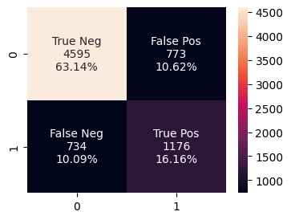

```python
# Calculating different metrics
dTree_train_perf = model_performance_classification(dTree, X_train_new, y_train_new)
print("Training performance:\n", dTree_train_perf)
dTree_test_perf = model_performance_classification(dTree, X_test_new, y_test_new)
print("Testing performance:\n", dTree_test_perf)
# Creating confusion matrix
make_confusion_matrix(dTree, X_test_new, y_test_new, figsize=(4, 3))
```

The model has a balanced recall, Precision, and F1 score.

I will now build a Random Forest model

```python
# Fitting the model
rf = RandomForestClassifier(random_state=1)
rf.fit(X_train_new, y_train_new)
```

```
RandomForestClassifier(random_state=1)
```

**Evaluation**

```
Training performance:
    Accuracy    Recall  Precision        F1
0   0.98251  0.960512   0.972512  0.966475
Testing performance:
    Accuracy   Recall  Precision        F1
0  0.823303  0.60733   0.683962  0.643372
```

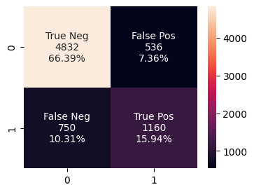

```python
# Calculating different metrics
rf_train_perf = model_performance_classification(rf, X_train_new, y_train_new)
print("Training performance:\n", rf_train_perf)
rf_test_perf = model_performance_classification(rf, X_test_new, y_test_new)
print("Testing performance:\n", rf_test_perf)
# Creating confusion matrix
make_confusion_matrix(rf, X_test_new, y_test_new, figsize=(4, 3))
```

This model has slightly better precision than decision tree but there is no significant change

**Tuning Decision tree model with GridSearchCV**

But, focusing only on Recall may significantly reduce Precision. So, let's try to optimise F1 score. But, Choose a model that gives better recall amongst all the models

```python
# Choose the type of classifier.
dTree_tuned = DecisionTreeClassifier(random_state=1)
# Grid of parameters to choose from
dt_param_grid = { # Fixed: Removed extra indentation
    "max_depth": [3, 5, 10, None],
    "min_samples_split": [2, 5, 10],
    "min_samples_leaf": [1, 2, 5],
    "criterion": ["gini", "entropy"]
}

# Type of scoring used to compare parameter combinations
scorer = metrics.make_scorer(
    metrics.f1_score
)  # Note that f1 score is chosen here as the scorer.

# Run the grid search
# Fixed: Replaced 'parameters' with 'dt_param_grid'
grid_obj = GridSearchCV(dTree_tuned, dt_param_grid, scoring=scorer, n_jobs=-1, verbose=1)
grid_obj = grid_obj.fit(X_train_new, y_train_new) # Fixed: Used the correct training data (X_train_new, y_train_new)

# Set the clf to the best combination of parameters (which achieves the best score)
dTree_tuned = grid_obj.best_estimator_

# Fit the best algorithm to the data.
dTree_tuned.fit(X_train_new, y_train_new) # Fixed: Used the correct training data (X_train_new, y_train_new)
```

```
Fitting 5 folds for each of 72 candidates, totalling 360 fits
```

```
DecisionTreeClassifier(max_depth=3, random_state=1)
```

```
Training performance:
    Accuracy   Recall  Precision       F1
0   0.82981  0.50258   0.768967  0.60787
Testing performance:
    Accuracy   Recall  Precision        F1
0  0.836768  0.51623     0.7888  0.624051
```

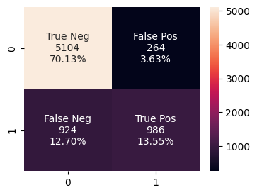

```python
# Calculating different metrics
dTree_tuned_train_perf = model_performance_classification(dTree_tuned, X_train_new, y_train_new) # Use X_train_new, y_train_new
print("Training performance:\n", dTree_tuned_train_perf)
dTree_tuned_test_perf = model_performance_classification(dTree_tuned, X_test_new, y_test_new) # Use X_test_new, y_test_new
print("Testing performance:\n", dTree_tuned_test_perf)
# Creating confusion matrix
make_confusion_matrix(dTree_tuned, X_test_new, y_test_new, figsize=(4, 3)) # Use X_test_new, y_test_new
```

This model has reduced recall to 51% which is in noway optimal. Lets, manual give class weights and try the model again. The dataset has dominatingly class 0 data. So, lets try to reverse the weights and see what happens

**Using class weights**

```python
# Choose the type of classifier.
dTree_tuned = DecisionTreeClassifier(class_weight={0: 0.20, 1: 0.80},random_state=42)
# using reverse class weights
# Grid of parameters to choose from
parameters = {
    "max_depth": np.arange(2, 8, 1),
    "min_samples_leaf": [5, 7, 10],
    "max_leaf_nodes": [3, 5, 10, 15, 20],
    "min_impurity_decrease": [0.001, 0.01, 0.1],
}

# Type of scoring used to compare parameter combinations
scorer = metrics.make_scorer(
    metrics.f1_score
)  # Note that f1 score is chosen here as the scorer.

# Run the grid search
grid_obj = GridSearchCV(dTree_tuned, parameters, scoring=scorer, n_jobs=-3,verbose=2)
grid_obj = grid_obj.fit(X_train_new, y_train_new)

# Set the clf to the best combination of parameters (which achieves the best score)
dTree_tuned = grid_obj.best_estimator_

# Fit the best algorithm to the data.
dTree_tuned.fit(X_train_new, y_train_new)
```

```
Fitting 5 folds for each of 270 candidates, totalling 1350 fits
```

```
DecisionTreeClassifier(class_weight={0: 0.2, 1: 0.8}, max_depth=2,
                       max_leaf_nodes=3, min_impurity_decrease=0.001,
                       min_samples_leaf=5, random_state=42)
```

```
Training performance:
    Accuracy    Recall  Precision        F1
0  0.725929  0.883554   0.487799  0.628571
Testing performance:
    Accuracy    Recall  Precision        F1
0  0.735779  0.890052   0.498096  0.638738
```

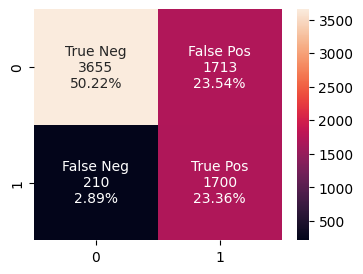

```python
# Calculating different metrics
dTree_tuned_train_perf = model_performance_classification(dTree_tuned, X_train_new, y_train_new)
print("Training performance:\n", dTree_tuned_train_perf)
dTree_tuned_test_perf = model_performance_classification(dTree_tuned, X_test_new, y_test_new)
print("Testing performance:\n", dTree_tuned_test_perf)
# Creating confusion matrix
make_confusion_matrix(dTree_tuned, X_test_new, y_test_new, figsize=(4, 3))
```

```python
# Choose the type of classifier.
rf_tuned = RandomForestClassifier(class_weight={0: 0.20, 1: 0.80}, random_state=42)

parameters = {
    "max_depth": list(np.arange(3, 10, 1)),
    "max_features": np.arange(0.5, 0.8, 0.1),
    "max_samples": np.arange(0.8, 1, 0.1),
    "min_samples_split": np.arange(2, 15, 5),
    "n_estimators": np.arange(20, 100, 20),
    "min_impurity_decrease": [0.001, 0.01, 0.1],
}


# Type of scoring used to compare parameter combinations
scorer = metrics.make_scorer(metrics.f1_score)

# Run the grid search
grid_obj = GridSearchCV(rf_tuned, parameters, scoring=scorer, cv=5, n_jobs=-1, verbose=2)
grid_obj = grid_obj.fit(X_train_new, y_train_new)

# Print the best parameters found
print("Best parameters found: ", grid_obj.best_params_)

# Set the clf to the best combination of parameters
rf_tuned = grid_obj.best_estimator_
```

```
Fitting 5 folds for each of 2016 candidates, totalling 10080 fits
Best parameters found:  {'max_depth': 3, 'max_features': 0.5, 'max_samples': 0.8, 'min_impurity_decrease': 0.001, 'min_samples_split': 2, 'n_estimators': 20}
```

```
Training performance:
    Accuracy    Recall  Precision        F1
0  0.727342  0.883554   0.489253  0.629778
Testing performance:
    Accuracy    Recall  Precision        F1
0  0.737153  0.890576   0.499559  0.640075
```

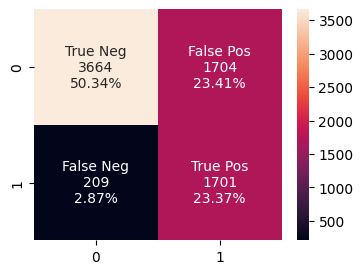

```python
# Calculating different metrics
rf_tuned_train_perf = model_performance_classification(rf_tuned, X_train_new, y_train_new)
print("Training performance:\n", rf_tuned_train_perf)
rf_tuned_test_perf = model_performance_classification(rf_tuned, X_test_new, y_test_new)
print("Testing performance:\n", rf_tuned_test_perf)
# Creating confusion matrix
make_confusion_matrix(rf_tuned, X_test_new, y_test_new, figsize=(4,3))
```

```python
# Choose the type of classifier.
rf_tuned_1 = RandomForestClassifier(class_weight= 'balanced', random_state=42)

parameters = {
    "max_depth": list(np.arange(3, 10, 1)),
    "max_features": [0.5, "sqrt"],
    "max_samples": np.arange(0.8, 1, 0.1),
    "min_samples_split": np.arange(2, 15, 5),
    "n_estimators": np.arange(20, 100, 20),
    "min_impurity_decrease": [0.001, 0.01],
}


# Type of scoring used to compare parameter combinations
scorer = metrics.make_scorer(metrics.f1_score)

# Run the grid search
grid_obj = GridSearchCV(rf_tuned_1, parameters, scoring=scorer, cv=5, n_jobs=-1, verbose=2)
grid_obj = grid_obj.fit(X_train_new, y_train_new)

# Print the best parameters found
print("Best parameters found: ", grid_obj.best_params_)

# Set the clf to the best combination of parameters
rf_tuned_1 = grid_obj.best_estimator_
```

```
Fitting 5 folds for each of 672 candidates, totalling 3360 fits
Best parameters found:  {'max_depth': 3, 'max_features': 0.5, 'max_samples': 0.8, 'min_impurity_decrease': 0.001, 'min_samples_split': 2, 'n_estimators': 20}
```

```
Training performance:
    Accuracy    Recall  Precision        F1
0  0.730522  0.879964   0.492528  0.631562
Testing performance:
    Accuracy    Recall  Precision       F1
0  0.738802  0.884817   0.501335  0.64003
```

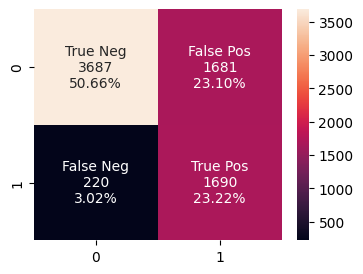

```python
# Calculating different metrics
rf_tuned_1_train_perf = model_performance_classification(rf_tuned_1, X_train_new, y_train_new)
print("Training performance:\n", rf_tuned_1_train_perf)
rf_tuned_1_test_perf = model_performance_classification(rf_tuned_1, X_test_new, y_test_new)
print("Testing performance:\n", rf_tuned_1_test_perf)
# Creating confusion matrix
make_confusion_matrix(rf_tuned_1, X_test_new, y_test_new, figsize=(4,3))
```

We performed tuning with both manually given and balanced class weights. Both had almost metrics. Lets compare the models and see which is better

```python
# test performance comparison

models_test_comp_df = pd.concat(
    [
        model_performance_classification(dTree, X_test_new, y_test_new).T,
        model_performance_classification(dTree_tuned, X_test_new, y_test_new).T,
        model_performance_classification(rf, X_test_new, y_test_new).T,
        model_performance_classification(rf_tuned_1, X_test_new, y_test_new).T
    ],
    axis=1,
)
models_test_comp_df.columns = [
    "Decision Tree ",
    "Decision Tree tuned",
    "Random Forest",
    "Random Forest balanced Tuned"
]
print("test performance comparison:")
models_test_comp_df
```

```
test performance comparison:
```

|  | Decision Tree | Decision Tree tuned | Random Forest | Random Forest balanced Tuned |
| --- | --- | --- | --- | --- |
| Accuracy | 0.792938 | 0.735779 | 0.823303 | 0.738802 |
| Recall | 0.615707 | 0.890052 | 0.607330 | 0.884817 |
| Precision | 0.603386 | 0.498096 | 0.683962 | 0.501335 |
| F1 | 0.609484 | 0.638738 | 0.643372 | 0.640030 |

Out of all the models, Random forest model has a good balance between precision, recall, and f1 score. But, the tuned random forest model has higher recall with decent precision and high f1-score

**Interpretation of the Metrics:**

F1-Score: 64%:

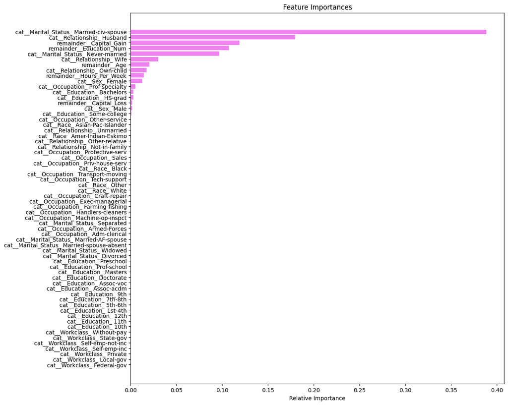

```python
# Get feature names after one-hot encoding
feature_names = preprocessor_new.get_feature_names_out()

importances = rf_tuned_1.feature_importances_
indices = np.argsort(importances)

plt.figure(figsize=(12, 12))
plt.title("Feature Importances")
plt.barh(range(len(indices)), importances[indices], color="violet", align="center")
plt.yticks(range(len(indices)), [feature_names[i] for i in indices])
plt.xlabel("Relative Importance")
plt.show()
```

Marital Status, Education, and relationships are the most important features

**Visualizing the tree**

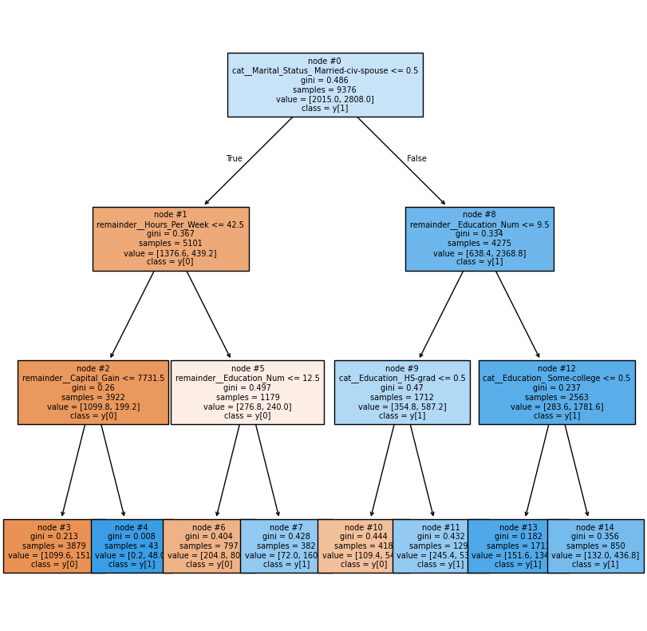

```python
plt.figure(figsize=(10, 10))
# Accessing the first decision tree from the Random Forest
tree.plot_tree(
    rf_tuned.estimators_[0],  # Selecting the first tree
    feature_names=feature_names,
    filled=True,
    fontsize=7,
    node_ids=True,
    class_names=True,
)
plt.show()
```

**Business insights from EDA and classification modeling**

**What can the organization do or implement to upward mobility in <=50k category**